# GIS Final

Darian

2023-12-06

# Introduction

The biodiversity of marine ecosystems is a complex and dynamic attribute, critically influenced by various environmental factors. This research is dedicated to a comprehensive analysis of how different environmental variables, including raft volume, distance from shore, and water quality, affect the biodiversity associated with these Sargassum rafts. Through rigorous data analysis, we aim to shed light on the patterns and relationships that define these unique marine environments.

Utilizing a dataset encompassing various measurements and observations related to Sargassum rafts and the associated macrofauna, we will explore several hypotheses. Each hypothesis targets specific aspects of the interaction between environmental conditions and biodiversity. Our findings are expected to contribute to the broader understanding of marine biodiversity dynamics, particularly in the context of floating seaweed ecosystems.

## Data Set Up

### Calculating Raft Volume

```r
raft_data$Volume <- raft_data$Length * raft_data$Width * raft_data$Thickness
```

### Calculating Biodiversity

```r
# Aggregate species counts per raft
species_counts <- fauna_data %>%
  group_by(Site, Species) %>%
  summarize(Count = n(), .groups = 'drop')

# Spread the data for Shannon-Weiner Index calculation
species_matrix <- species_counts %>%
  pivot_wider(names_from = Species, values_from = Count, values_fill = list(Count = 0))

# Calculate Shannon-Weiner Index for each raft
raft_biodiversity <- species_matrix %>%
  rowwise() %>%
  mutate(Shannon_Index = diversity(c_across(-Site), index = "shannon"))

# Select only Site and Shannon_Index
raft_biodiversity <- raft_biodiversity %>%
  select(Site, Shannon_Index)

# Merge raft volume data
raft_bio <- merge(raft_data, raft_biodiversity, by = "Site")
```

## Hypothesis 1: The Relationship Between Sargassum Raft Volume/Type and Biodiversity

### Volume vs. Biodiversity - Correlation

#### Methods

```r
correlation_result <- cor.test(raft_bio$Volume, raft_bio$Shannon_Index)
```

#### Results

```r
correlation_result
```

```
##
##  Pearson's product-moment correlation
##
## data:  raft_bio$Volume and raft_bio$Shannon_Index
## t = -1.5344, df = 148, p-value = 0.1271
## alternative hypothesis: true correlation is not equal to 0
## 95 percent confidence interval:
##  -0.27978496  0.03584609
## sample estimates:
##        cor
## -0.1251343
```

### Raft Type vs. Biodiversity - Normal - ANOVA

#### Methods

- Check Assumptions

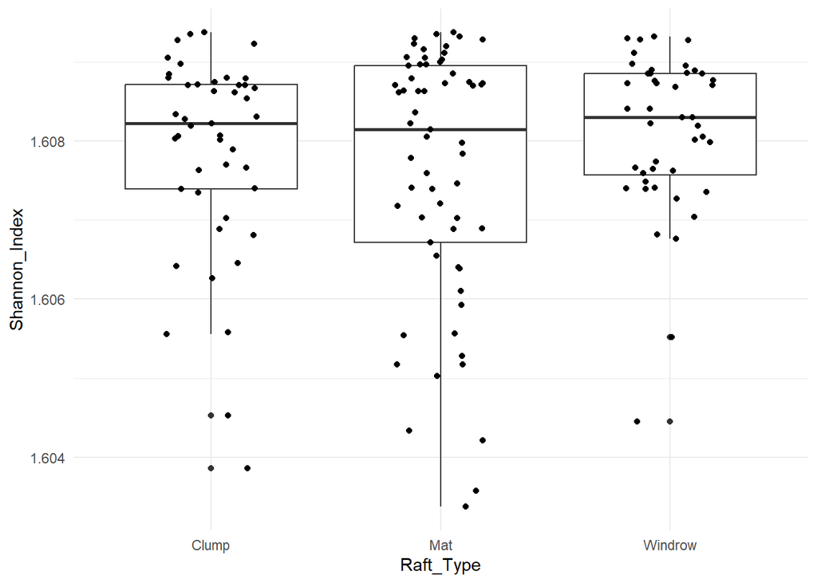

```r
# Normality check
normal_check <- ggplot(raft_bio, aes(x = Raft_Type, y = Shannon_Index)) +
  geom_boxplot() +
  geom_jitter(width = 0.2) +
  theme_minimal()

#Print the Results
normal_check
```

```r
# Homogeneity of variances check
bartlett_anova <- bartlett.test(Shannon_Index ~ Raft_Type, data = raft_bio)

# Print the results
bartlett_anova
```

```
##
##  Bartlett test of homogeneity of variances
##
## data:  Shannon_Index by Raft_Type
## Bartlett's K-squared = 10.874, df = 2, p-value = 0.004352
```

- If assumptions are met, run an ANOVA, if not, use Kruskal-Wallis test

```r
anova_result <- aov(Shannon_Index ~ Raft_Type, data = raft_bio)

anova_summary <- summary(anova_result)
```

#### Results

```r
anova_summary
```

```
##              Df    Sum Sq   Mean Sq F value Pr(>F)
## Raft_Type     2 6.310e-06 3.156e-06   1.732  0.181
## Residuals   147 2.678e-04 1.822e-06
```

- Post-hoc analysis if ANOVA is significant (Use if ANOVA result is significant and you want to know which groups differ) if (summary(anova_result)$`Pr(>F)`[1] < 0.05) { TukeyHSD(anova_result) }

### Raft Type vs. Biodiversity - Non-Normal - Kruskal-Wallace

#### Methods

```r
kruskal_result <- kruskal.test(Shannon_Index ~ Raft_Type, data = raft_bio)
```

#### Results

```r
kruskal_result
```

```
##
##  Kruskal-Wallis rank sum test
##
## data:  Shannon_Index by Raft_Type
## Kruskal-Wallis chi-squared = 1.1687, df = 2, p-value = 0.5575
```

### Community Composition - nMDS

#### Methods

```r
# Prepare a community data matrix
# Assuming fauna_data has columns 'Site' for rafts and 'Species' for species names
community_matrix <- fauna_data %>%
  group_by(Site, Species) %>%
  summarize(Count = n(), .groups = 'drop') %>%
  pivot_wider(names_from = Species, values_from = Count, values_fill = list(Count = 0))

# Remove the Site column for nMDS analysis
community_matrix <- select(community_matrix, -Site)
```

##### Results

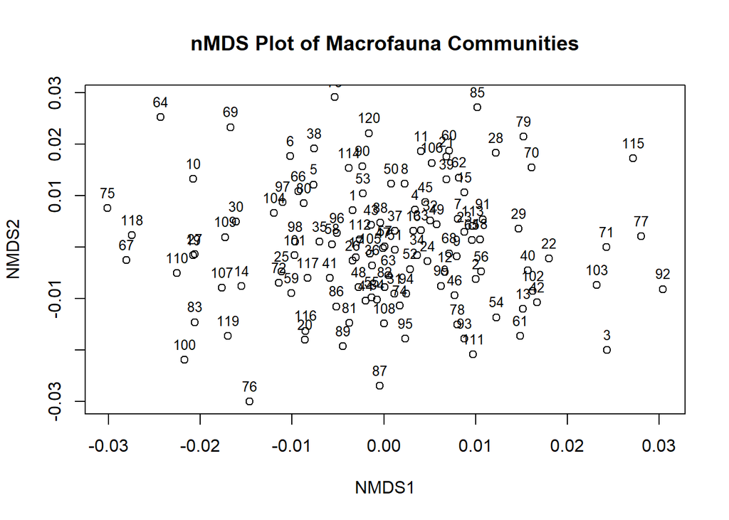

Figure 2: Non-metric multidimensional scaling plot depicting the community composition of macrofauna associated with Sargassum rafts. The plot illustrates similarities and differences in community structures across various sampling sites.

```r
# Run nMDS Analysis
nmds_results <- metaMDS(community_matrix, distance = "bray", trymax = 100)

# Plot the nMDS results
plot(nmds_results$points[,1], nmds_results$points[,2],
     xlab="NMDS1", ylab="NMDS2", main="nMDS Plot of Macrofauna Communities")
text(nmds_results$points[,1], nmds_results$points[,2],
     labels = rownames(nmds_results$points), cex = 0.8, pos = 3)
```

## Hypothesis 2: The Relationship Between Sargassum Raft Volume/Type, Biodiversity, and Beauforts Force

### Raft Volume vs. Beaufort Force - Normal - ANOVA

#### Methods

- Check Assumptions

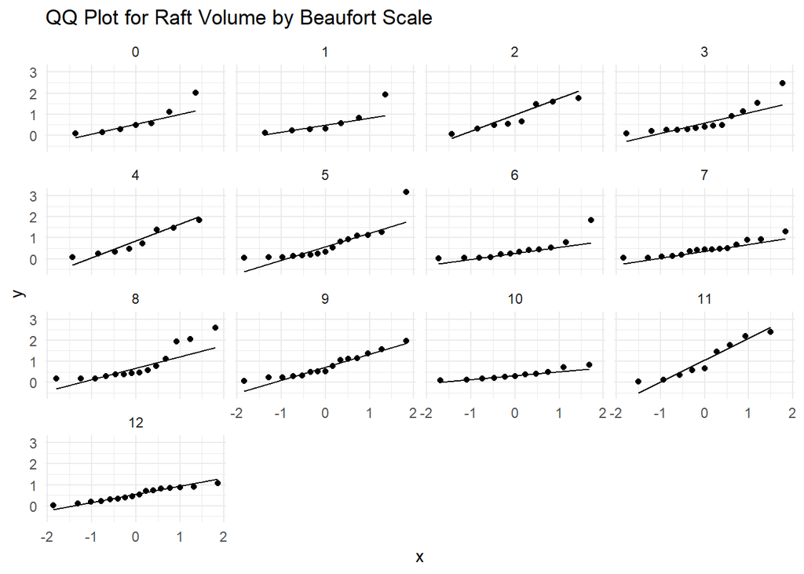

```r
# Assuming 'raft_bio' is your data frame with BF and Volume
 # QQ Plot for Biodiversity Index
 BF_Vol_norm <- ggplot(raft_bio, aes(sample = Volume)) +
   geom_qq() +
   geom_qq_line() +
   facet_wrap(~ BF) +
   theme_minimal() +
   ggtitle("QQ Plot for Raft Volume by Beaufort Scale")

 BF_Vol_norm
```

```r
 # Group by Beaufort Scale and apply Shapiro-Wilk test to each group
 normality_results <- raft_bio %>%
   group_by(BF) %>%
   summarize(shapiro_p_value = shapiro.test(Volume)$p.value)

 # View the results
 normality_results
```

[output not shown]

```r
# Homogeneity of variances check
bartlett_anova2 <- bartlett.test(Volume ~ BF, data = raft_bio)

# Print the results
bartlett_anova2
```

```
##
##  Bartlett test of homogeneity of variances
##
## data:  Volume by BF
## Bartlett's K-squared = 32.493, df = 12, p-value = 0.001161
```

- If assumptions are met, run an ANOVA, if not, use Kruskal-Wallis test

```r
anova_result2 <- aov(Volume ~ BF, data = raft_bio)

anova_summary2 <- summary(anova_result2)
```

#### Results

```r
anova_summary2
```

```
##              Df Sum Sq Mean Sq F value Pr(>F)
## BF            1   0.04  0.0436   0.113  0.737
## Residuals   148  56.88  0.3843
```

- Post-hoc analysis if ANOVA is significant (Use if ANOVA result is significant and you want to know which groups differ) if (summary(anova_result)$`Pr(>F)`[1] < 0.05) { TukeyHSD(anova_result) }

### Raft Volume vs. Beaufort Force - Non-Normal - Kruskal - Wallace

#### Methods

```r
kruskal_result2 <- kruskal.test(Volume ~ BF, data = raft_bio)
```

#### Results

```r
kruskal_result2
```

```
##
##  Kruskal-Wallis rank sum test
##
## data:  Volume by BF
## Kruskal-Wallis chi-squared = 11.478, df = 12, p-value = 0.4885
```

### Raft Type vs. Beaufort Force - Non-Normal - Chi-square

#### Methods

```r
# For raft type, a Chi-squared test might be more appropriate because Raft_Type is a categorical variable

# Assuming Raft_Type is a factor in raft_data
chisq_test <- chisq.test(table(raft_data$Raft_Type, raft_data$BF))
```

#### Results

```r
chisq_test
```

```
##
##  Pearson's Chi-squared test
##
## data:  table(raft_data$Raft_Type, raft_data$BF)
## X-squared = 40.711, df = 24, p-value = 0.01791
```

### Biodiversity vs. Beaufort Force - Regression

#### Methods

```r
# Assuming 'raft_bio' is your data frame with BF and Biodiversity

regression_biodiversity <- lm(Shannon_Index ~ BF, data = raft_bio)
```

#### Results

```r
summary(regression_biodiversity)
```

```
##
## Call:
## lm(formula = Shannon_Index ~ BF, data = raft_bio)
##
## Residuals:
##        Min         1Q     Median         3Q        Max
## -0.0046020 -0.0005013  0.0004123  0.0009836  0.0016537
##
## Coefficients:
##              Estimate Std. Error  t value Pr(>|t|)
## (Intercept) 1.608e+00  2.371e-04 6779.285   <2e-16 ***
## BF          2.516e-05  3.163e-05    0.795    0.428
## ---
## Signif. codes:  0 '***' 0.001 '**' 0.01 '*' 0.05 '.' 0.1 ' ' 1
##
## Residual standard error: 0.001358 on 148 degrees of freedom
## Multiple R-squared:  0.004258,   Adjusted R-squared:  -0.00247
## F-statistic: 0.6328 on 1 and 148 DF,  p-value: 0.4276
```

### Biodiversity vs. Volume vs. Beaufort Force - Multiple Regression

#### Methods

```r
multiple_regression_model <- lm(Shannon_Index ~ Volume + BF, data = raft_bio)
```

#### Results

```r
summary(multiple_regression_model)
```

```
##
## Call:
## lm(formula = Shannon_Index ~ Volume + BF, data = raft_bio)
##
## Residuals:
##        Min         1Q     Median         3Q        Max
## -0.0045518 -0.0006345  0.0003792  0.0009639  0.0020304
##
## Coefficients:
##               Estimate Std. Error  t value Pr(>|t|)
## (Intercept)  1.608e+00  2.665e-04 6032.795   <2e-16 ***
## Volume      -2.708e-04  1.793e-04   -1.511    0.133
## BF           2.385e-05  3.151e-05    0.757    0.450
## ---
## Signif. codes:  0 '***' 0.001 '**' 0.01 '*' 0.05 '.' 0.1 ' ' 1
##
## Residual standard error: 0.001352 on 147 degrees of freedom
## Multiple R-squared:  0.01948,    Adjusted R-squared:  0.006139
## F-statistic:  1.46 on 2 and 147 DF,  p-value: 0.2355
```